# EasyStat_help

wentao

2020/6/13

# 差异分析完整解决方案

本次更新：

- 修改整个R包，包括包名；安装EasyStat包，本次安装包只要你可以用下载，应该可以安装成功。因为我已经将全部的依赖都写好了.
- 增加多组展示同一张图的可视化方式。
- 修改字母标记无法显示完整问题
- 增加line展示差异ns是否显示的参数。
- 增加线柱图展示。参考（NBT线虫工程菌）。

## EasyStat 使用指南

导入包和数据，数据均来自真实试验和文公开文献下载，通过调整分组加入。

```r
# 导入差异分析包
library(EasyStat)
library(ggplot2)# 用于作图
library("dplyr")# 用于数据处理


#使用内置数据1
data(data_wt)

#内置数据2
data(env)
```

### 基于单个指标的统计分析

正态检验和方差齐性分析，使用?NorNorCVTest查看帮助信息

```r
# 使用?NorNorCVTest查看帮助信息
##使用案例
NorCV = NorNorCVTest(data = data_wt, i= 4,method_cv = "leveneTest")
#提取正态检验结果
NorCV[[1]]
```

```
##             No         Name         W   p.value norm.test
## 1            1           CF 0.9385422 0.6474760      Norm
## 2            2           CK 0.9306138 0.5848500      Norm
## 3            3          Rhi 0.9651627 0.8585061      Norm
## 4            4           WT 0.9756280 0.9278774      Norm
## 5 Test Method: Shapiro-Wilk        NA        NA      <NA>
```

```r
#提取方差齐性检验结果
NorCV[[2]]
```

```
## [1] 0.247
```

norm.test会按照分组告诉大家是否符合正态分布。

### 方差分析(aovMcomper)

- data:输入数据框，第一列为样本编号，第二列为分组，注意分组标签必须设定为group，第三列以后就是测定或者收集的指标了
- i:代表您想要进行统计的列，比如：第三列：i = 3
- method_Mc:选择需要使用的多重比较方法，这里又多种方法可供选择：method_Mc == “LSD”;method_Mc == “SNK”;method_Mc == “Duncan”;method_Mc == “scheffe”

```r
# ?aovMcomper
result= aovMcomper (data = data_wt, i= 6,method_Mc = "Tukey")
# 提取多重比较结果
result[[1]]
```

```
##     groups group
## CF      a     CF
## CK      a     CK
## Rhi      b   Rhi
## WT      a     WT
```

```r
#提取方差检验结果
result[[2]]
```

```
## Call:
##    aov(formula = count ~ group, data = ss)
##
## Terms:
##                        group    Residuals
## Sum of Squares  169573500000   3387000000
## Deg. of Freedom            3           20
##
## Residual standard error: 13013.45
## Estimated effects may be unbalanced
```

结果中多重比较的展示全部使用字母表示了，虽然许多多种比较方法默认展示方式不同，但是我已经在包中将这些展示方式调整一致为字母。

### 非参数检验

两个参数代表的意义与方差分析的两个相同；

- data:输入数据框，第一列为样本编号，第二列为分组，注意分组标签必须设定为group，第三列以后就是妮妮测定或者收集的指标了
- i:代表您想要进行统计的列，比如：第三列：i = 3

```r
# ?KwWlx
res = KwWlx(data = data_wt, i= 6)
# 调用非参数两两比较结果：字母标记展示
res[[1]]
```

```
##     groups group
## CF      ab    CF
## CK       a    CK
## Rhi      c   Rhi
## WT       b    WT
```

```r
#表格展示两两之间差异结果
res[[2]]
```

```
## # A tibble: 6 x 8
##   .y.   group1 group2       p p.adj p.format p.signif method
##   <chr> <chr>  <chr>    <dbl> <dbl> <chr>    <chr>    <chr>
## 1 count CF     CK     0.123   0.25  0.1228   ns       Wilcoxon
## 2 count CF     Rhi    0.00470 0.028 0.0047   **       Wilcoxon
## 3 count CF     WT     0.864   0.86  0.8643   ns       Wilcoxon
## 4 count CK     Rhi    0.00470 0.028 0.0047   **       Wilcoxon
## 5 count CK     WT     0.0488  0.15  0.0488   *        Wilcoxon
## 6 count Rhi    WT     0.00470 0.028 0.0047   **       Wilcoxon
```

## 差异可视化方案（两种差异表示，三种图形展示）

### 柱状图展示方差分析或非参数检验结果（aovMuiBarPlot）

在这个包中将差异检测和出图部分分离，方便选择合适的图表和差异可视化的策略。最终要的参数是result ：为前面差异分析结果中的第一个表单，格式为第一列差异显著字母，第二列分组标签，列名，分组标签。如果只是用可视化的函数，直接从外面导入类似数据即可。

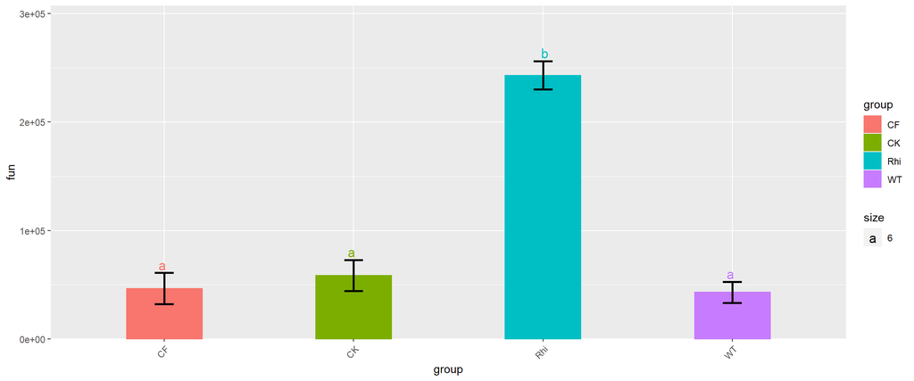

```r
# ?aovMuiBarPlot
###----使用方差检验结果和多重比较结果做展示：  柱状图展示
PlotresultBar = aovMuiBarPlot(data = data_wt, i= 6,sig_show ="abc",result = result[[1]])
#提取结果
PlotresultBar[[1]]
```

```r
#提取方差分析或非参数检验结果
PlotresultBar[[2]]
```

```
##   Row.names groups group   mean        SD
## 1        CF     a     CF  46500 14418.738
## 2        CK     a     CK  58500 14418.738
## 3       Rhi      b   Rhi 243000 13007.690
## 4        WT     a     WT  43000  9612.492
```

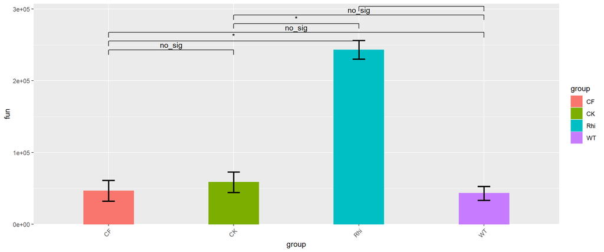

```r
# ?aovMuiBarPlot
###----使用方差检验结果和多重比较结果做展示：  柱状图展示
PlotresultBar = aovMuiBarPlot(data = data_wt, i= 6,sig_show ="line",result = result[[1]])
#提取结果
PlotresultBar[[1]]
```

```r
#提取方差分析或非参数检验结果
PlotresultBar[[2]]
```

```
##   Row.names groups group   mean        SD
## 1        CF     a     CF  46500 14418.738
## 2        CK     a     CK  58500 14418.738
## 3       Rhi      b   Rhi 243000 13007.690
## 4        WT     a     WT  43000  9612.492
```

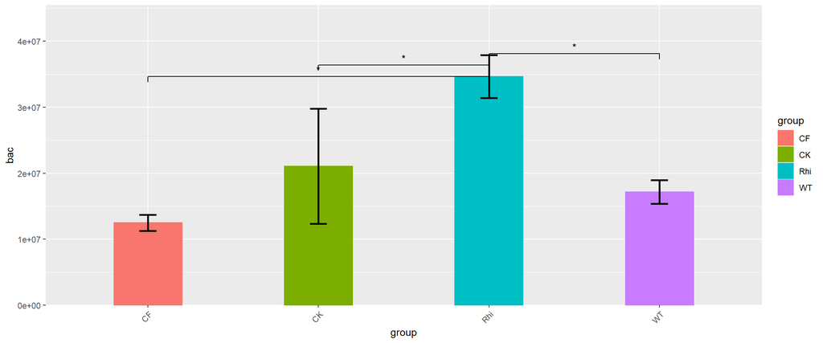

```r
# ?aovMuiBarPlot
###----使用方差检验结果和多重比较结果做展示：  柱状图展示
PlotresultBar = aovMuiBarPlot(data = data_wt, i= 5,sig_show ="line",result = result[[1]],ns =TRUE)
#提取结果
PlotresultBar[[1]]
```

```r
#提取方差分析或非参数检验结果
PlotresultBar[[2]]
```

```
##   Row.names groups group     mean      SD
## 1        CF     a     CF 12500000 1224745
## 2        CK     a     CK 21050000 8728746
## 3       Rhi      b   Rhi 34650000 3251923
## 4        WT     a     WT 17150000 1784096
```

- data：输入数据框，第一列为样本编号，第二列为分组，注意分组标签必须设定为group，第三列以后就是测定或者收集的指标了
- i：代表您想要进行统计的列，比如：第三列：i = 3
- sig_show：代表差异展示方式；sig_show =“abc”是使用字母表示;sig_show =“line”是使用连线和星号表示；如果是NA，那么就不显示显著性结果
- result：代表显著性差异分析结果，是一个数据框，第一列是显著性差异字母，第二列是分组group

#### 箱线图展示方差分析或非参数检验结果（aovMuiBoxP）

- data：输入数据框，第一列为样本编号，第二列为分组，注意分组标签必须设定为group，第三列以后就是测定或者收集的指标了
- i：代表您想要进行统计的列，比如：第三列：i = 3
- sig_show：代表差异展示方式；sig_show =“abc”是使用字母表示;sig_show =“line”是使用连线和星号表示；如果是NA，那么就不显示显著性结果
- result：代表显著性差异分析结果，是一个数据框，第一列是显著性差异字母，第二列是分组group

```r
# ?aovMuiBoxP
# #使用案例
PlotresultBox = aovMuiBoxP(data = data_wt, i= 6,sig_show ="abc",result = result[[1]])
# 提取检验结果
PlotresultBox[[2]]
```

```
##      ID group     dd stat      y
## 1   CF1    CF  72000   a   83400
## 2   CF2    CF  36000   a   83400
## 3   CF3    CF  36000   a   83400
## 4   CF4    CF  54000   a   83400
## 5   CF5    CF  36000   a   83400
## 6   CF6    CF  45000   a   83400
## 7   CK1    CK  84000   a   95400
## 8   CK2    CK  48000   a   95400
## 9   CK3    CK  48000   a   95400
## 10  CK4    CK  66000   a   95400
## 11  CK5    CK  48000   a   95400
## 12  CK6    CK  57000   a   95400
## 13 Rhi1   Rhi 264000    b 275400
## 14 Rhi2   Rhi 240000    b 275400
## 15 Rhi3   Rhi 228000    b 275400
## 16 Rhi4   Rhi 252000    b 275400
## 17 Rhi5   Rhi 234000    b 275400
## 18 Rhi6   Rhi 240000    b 275400
## 19  WT1    WT  60000   a   71400
## 20  WT2    WT  36000   a   71400
## 21  WT3    WT  36000   a   71400
## 22  WT4    WT  48000   a   71400
## 23  WT5    WT  36000   a   71400
## 24  WT6    WT  42000   a   71400
```

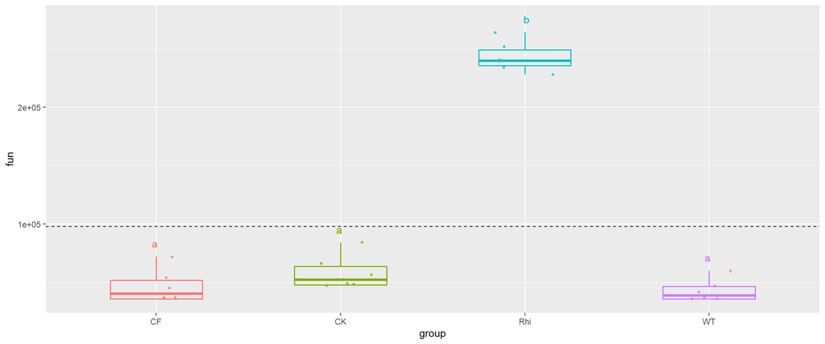

```r
#提取图片
p = PlotresultBox[[1]]
p
```

```r
# ?aovMuiBoxP
# #使用案例
PlotresultBox = aovMuiBoxP(data = data_wt, i= 6,sig_show ="line",result = result[[1]])
# 提取检验结果
PlotresultBox[[2]]
```

```
##      ID group     dd stat      y
## 1   CF1    CF  72000   a   83400
## 2   CF2    CF  36000   a   83400
## 3   CF3    CF  36000   a   83400
## 4   CF4    CF  54000   a   83400
## 5   CF5    CF  36000   a   83400
## 6   CF6    CF  45000   a   83400
## 7   CK1    CK  84000   a   95400
## 8   CK2    CK  48000   a   95400
## 9   CK3    CK  48000   a   95400
## 10  CK4    CK  66000   a   95400
## 11  CK5    CK  48000   a   95400
## 12  CK6    CK  57000   a   95400
## 13 Rhi1   Rhi 264000    b 275400
## 14 Rhi2   Rhi 240000    b 275400
## 15 Rhi3   Rhi 228000    b 275400
## 16 Rhi4   Rhi 252000    b 275400
## 17 Rhi5   Rhi 234000    b 275400
## 18 Rhi6   Rhi 240000    b 275400
## 19  WT1    WT  60000   a   71400
## 20  WT2    WT  36000   a   71400
## 21  WT3    WT  36000   a   71400
## 22  WT4    WT  48000   a   71400
## 23  WT5    WT  36000   a   71400
## 24  WT6    WT  42000   a   71400
```

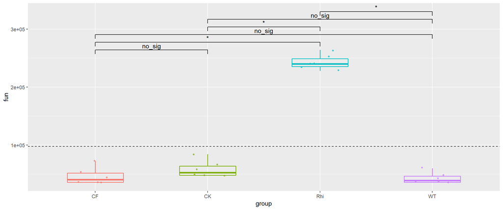

```r
#提取图片
p = PlotresultBox[[1]]
p
```

```r
# ?aovMuiBoxP
# #使用案例
PlotresultBox = aovMuiBoxP(data = data_wt, i= 6,sig_show ="line",result = result[[1]],ns = TRUE)
# 提取检验结果
PlotresultBox[[2]]
```

```
##      ID group     dd stat      y
## 1   CF1    CF  72000   a   83400
## 2   CF2    CF  36000   a   83400
## 3   CF3    CF  36000   a   83400
## 4   CF4    CF  54000   a   83400
## 5   CF5    CF  36000   a   83400
## 6   CF6    CF  45000   a   83400
## 7   CK1    CK  84000   a   95400
## 8   CK2    CK  48000   a   95400
## 9   CK3    CK  48000   a   95400
## 10  CK4    CK  66000   a   95400
## 11  CK5    CK  48000   a   95400
## 12  CK6    CK  57000   a   95400
## 13 Rhi1   Rhi 264000    b 275400
## 14 Rhi2   Rhi 240000    b 275400
## 15 Rhi3   Rhi 228000    b 275400
## 16 Rhi4   Rhi 252000    b 275400
## 17 Rhi5   Rhi 234000    b 275400
## 18 Rhi6   Rhi 240000    b 275400
## 19  WT1    WT  60000   a   71400
## 20  WT2    WT  36000   a   71400
## 21  WT3    WT  36000   a   71400
## 22  WT4    WT  48000   a   71400
## 23  WT5    WT  36000   a   71400
## 24  WT6    WT  42000   a   71400
```

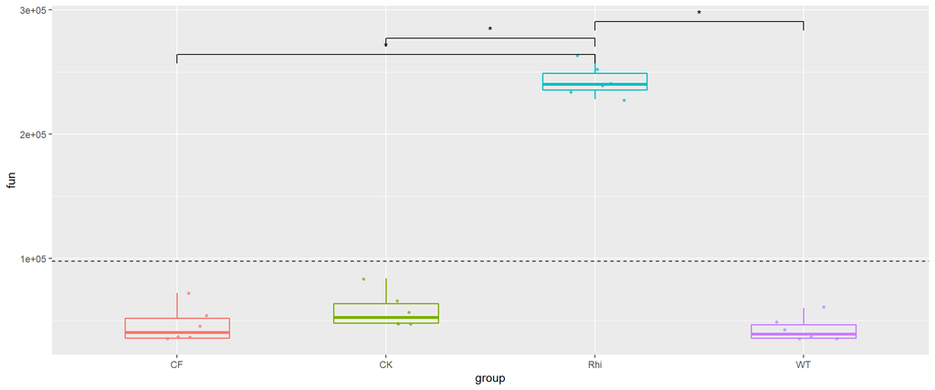

```r
#提取图片
p = PlotresultBox[[1]]
p
```

### 点柱图-完美解决柱状图无法展示样本信息的缺陷

```r
result= aovMcomper (data = data_wt, i= 6,method_Mc = "Tukey")
# # 提取多重比较结果
result[[1]]
```

```
##     groups group
## CF      a     CF
## CK      a     CK
## Rhi      b   Rhi
## WT      a     WT
```

```r
PlotresultBox = aovMuiBoxBarP(data = data_wt, i= 6,sig_show ="line",result = result[[1]],ns = TRUE)
```

```
## [1] 6
```

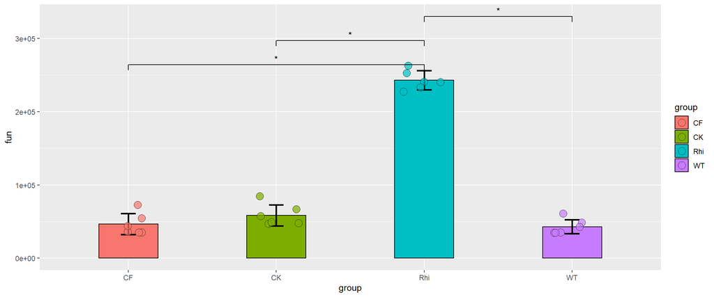

```r
#提取图片
p = PlotresultBox[[1]]
p
```

```r
PlotresultBox = aovMuiBoxBarP(data = data_wt, i= 6,sig_show ="line",result = result[[1]],ns = FALSE)
```

```
## [1] 6
```

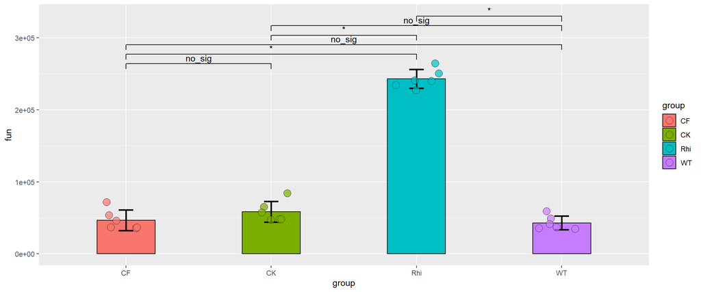

```r
#提取图片
p = PlotresultBox[[1]]
p
```

```r
PlotresultBox = aovMuiBoxBarP(data = data_wt, i= 6,sig_show ="line",result = result[[1]],ns = TRUE)
```

```
## [1] 6
```

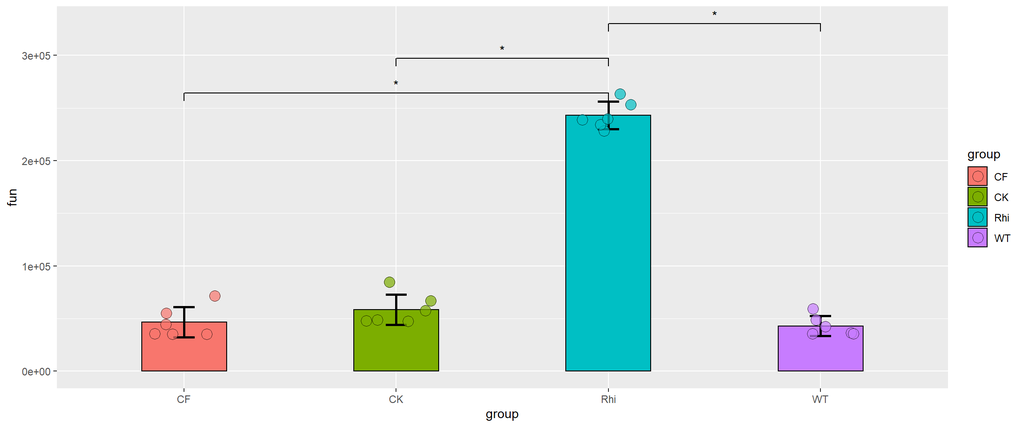

```r
#提取图片
p = PlotresultBox[[1]]
p
```

## 多指标模式

### 多个指标同时做正态检验和方差齐性分析（MuiNorCV）

这里对多组数据进行分析，结果我是用T或F代表，方便阅读。

- data：输入数据框，第一列为样本编号，第二列为分组，注意分组标签必须设定为group，第三列以后就是测定或者收集的指标了
- num：代表您想要进行统计的列,这里可以输入多个列，只需要指定列号即可：例如：num = c(4:6)
- method_cv：代表选择方差齐性的方法，有两种可供选择：method_cv == “bartlett.test” ;method_cv == “leveneTest”

```r
dim(data_wt)
```

```
## [1] 24 12
```

```r
# ?MuiNorCV
# 使用案例
norCv = MuiNorCV(data = data_wt,num = c(4:10),method_cv = "leveneTest")
#展示正态检验和方差齐性结果
norCv
```

```
##      DI      cor    CV
## [1,] "AP"    "TRUE" "TRUE"
## [2,] "bac"   "TRUE" "FALSE"
## [3,] "fun"   "TRUE" "TRUE"
## [4,] "micro" "TRUE" "TRUE"
## [5,] "NH4.N" "TRUE" "TRUE"
## [6,] "NO3.N" "TRUE" "FALSE"
## [7,] "pH"    "TRUE" "TRUE"
```

这里由于指标比较多，所以我将结果进行简化，直接使用ture和false来提示大家，cor是正态性检测组，cv是方差齐性检测。

#### 多个指标方差检验（MuiaovMcomper）

- data：输入数据框，第一列为样本编号，第二列为分组，注意分组标签必须设定为group，第三列以后就是测定或者收集的指标了
- num：代表您想要进行统计的列,这里可以输入多个列，只需要指定列号即可：例如：num = c(4:6)
- method_Mc：选择需要使用的多重比较方法，这里又多种方法可供选择：method_Mc = “LSD”;method_Mc = “SNK”;method_Mc = “Duncan”;method_Mc =“scheffe”

```r
# ? MuiaovMcomper
# #使用案例
result = MuiaovMcomper(data = data_wt,num = c(4:6),method_Mc = "Tukey")
#提取每个指标方差检验多重比较结果
result
```

```
##      AP bac fun
## CF  a   a    a
## CK    c  b   a
## Rhi  b    c   b
## WT   bc ab   a
```

同样，多个指标展示按照指标每列为一组检测结果。

### 多个指标非参数检验（MuiKwWlx）

- data：输入数据框，第一列为样本编号，第二列为分组，注意分组标签必须设定为group，第三列以后就是测定或者收集的指标了
- num：代表您想要进行统计的列,这里可以输入多个列，只需要指定列号即可：例如：num = c(4:6)

```r
# ? MuiKwWlx
# #使用案例
result = MuiKwWlx(data = data_wt,num = c(4:6))
#提取每个指标非参数检验多重比较结果
result
```

```
##     AP bac fun
## CF   a   a  ab
## CK   b  ab   a
## Rhi  c   c   c
## WT   d   b   b
```

### 多组数据可视化差异分析结果： 柱状图（MuiPlotresultBar）

多组指标分开出图，比较麻烦的是图形的保存，如果还需要让你一个一个保存图片，那也是相当繁琐的，所以这里我设置了自动保存，也只有这种方式是自动保存，其他单个，多组分面图形较少，所以就可以自己保存。

我让该函数自动保存每个指标的出图文件到当前文件夹中。这些文件以该指标名称命名；

- data：输入数据框，第一列为样本编号，第二列为分组，注意分组标签必须设定为group，第三列以后就是妮妮测定或者收集的指标了
- num：代表您想要进行统计的列,这里可以输入多个列，只需要指定列号即可：例如：num = c(4:6)
- sig_show：代表差异展示方式；sig_show =“abc”是使用字母表示;sig_show =“line”是使用连线和星号表示；如果是NA，那么就不显示显著性结果
- result：代表显著性差异分析结果，是一个数据框，每一列是显著性标记字母,MuiKwWlx

```r
# ?MuiPlotresultBar
# # #使用案例
result = MuiKwWlx(data = data_wt,num = c(4:6))
result
```

```
##     AP bac fun
## CF   a   a  ab
## CK   b  ab   a
## Rhi  c   c   c
## WT   d   b   b
```

```r
# #结果直接输出到文件夹中
MuiPlotresultBar(data = data_wt,num = c(4:6),result = result ,sig_show ="line")
```

### 多组数据可视化差异分析结果：箱线图（MuiPlotresultBox）

我让该函数自动保存每个指标的出图文件到当前文件夹中。这些文件以该指标名称命名；

- data：输入数据框，第一列为样本编号，第二列为分组，注意分组标签必须设定为group，第三列以后就是妮妮测定或者收集的指标了
- num：代表您想要进行统计的列,这里可以输入多个列，只需要指定列号即可：例如：num = c(4:6)
- sig_show：代表差异展示方式；sig_show =“abc”是使用字母表示;sig_show =“line”是使用连线和星号表示；如果是NA，那么就不显示显著性结果
- result：代表显著性差异分析结果，是一个数据框，每一列是显著性标记字母,MuiKwWlx

```r
# ?MuiPlotresultBox
#使用案例
result = MuiKwWlx(data = data_wt,num = c(4:8))
result
```

```
##     AP bac fun micro NH4.N
## CF   a   a  ab     a     a
## CK   b  ab   a     a     b
## Rhi  c   c   c     b    ab
## WT   d   b   b     a    ab
```

```r
# #直接出图到文件夹中
MuiPlotresultBox(data = data_wt,num = c(4:8),result = result,sig_show ="abc")
```

### 线柱图

输入和箱线图一致

```r
# ?MuiPlotresultBox
#使用案例
result = MuiKwWlx(data = data_wt,num = c(4:8))
result
```

```
##     AP bac fun micro NH4.N
## CF   a   a  ab     a     a
## CK   b  ab   a     a     b
## Rhi  c   c   c     b    ab
## WT   d   b   b     a    ab
```

```r
# #直接出图到文件夹中
MuiPlotReBoxBar(data = data_wt,num = c(4:8),result = result,sig_show ="line")
```

```
## [1] 4
```

```
## [1] 5
```

```
## [1] 6
```

```
## [1] 7
```

```
## [1] 8
```

#### 差异结果展示：分面展示柱状图：(FacetMuiPlotresultBar)

更新: - 由于不同指标坐标轴范围不同，分面添加显著性标示会让最高点的标示遮盖，已解决

- data：输入数据框，第一列为样本编号，第二列为分组，注意分组标签必须设定为group，第三列以后就是妮妮测定或者收集的指标了
- num：代表您想要进行统计的列,这里可以输入多个列，只需要指定列号即可：例如：num = c(4:6)
- sig_show：代表差异展示方式；sig_show =“abc”是使用字母表示;sig_show =“line”是使用连线和星号表示；如果是NA，那么就不显示显著性结果
- result：代表显著性差异分析结果，是一个数据框，每一列是显著性标记字母,MuiKwWlx
- ncol:代表分面展示每一行放几张图

```r
# ?FacetMuiPlotresultBar
# # #使用案例
result = MuiaovMcomper(data = data_wt,num = c(4:7),method_Mc = "Tukey")
result
```

```
##      AP bac fun micro
## CF  a   a    a     a
## CK    c  b   a     a
## Rhi  b    c   b     b
## WT   bc ab   a     a
```

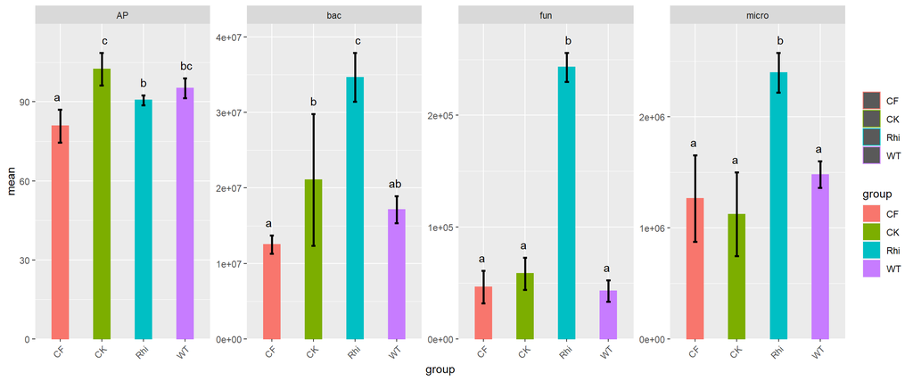

```r
result1 = FacetMuiPlotresultBar(data = data_wt,num = c(4:7),result = result,sig_show ="abc",ncol = 4 )
result1[[1]]
```

### 差异结果展示：分面展示箱线图：(FacetMuiPlotresultBox)

- data：输入数据框，第一列为样本编号，第二列为分组，注意分组标签必须设定为group，第三列以后就是妮妮测定或者收集的指标了
- num：代表您想要进行统计的列,这里可以输入多个列，只需要指定列号即可：例如：num = c(4:6)
- sig_show：代表差异展示方式；sig_show =“abc”是使用字母表示;sig_show =“line”是使用连线和星号表示；如果是NA，那么就不显示显著性结果
- result：代表显著性差异分析结果，是一个数据框，每一列是显著性标记字母,MuiKwWlx
- ncol:代表分面展示每一行放几张图

```r
# ?FacetMuiPlotresultBox
# #使用案例
result = MuiKwWlx(data = data_wt,num = c(4:7))
result
```

```
##     AP bac fun micro
## CF   a   a  ab     a
## CK   b  ab   a     a
## Rhi  c   c   c     b
## WT   d   b   b     a
```

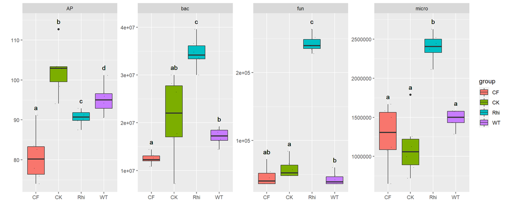

```r
#
result1 = FacetMuiPlotresultBox(data = data_wt,num = c(4:7),result = result,sig_show ="abc",ncol = 4 )
result1[[1]]
```

使用两种方法，我们可以对比非参数检验和方差检验结果是否一致

### 下面使用线柱图展示

```r
# #使用案例
result = MuiKwWlx(data = data_wt,num = c(4:7))
result
```

```
##     AP bac fun micro
## CF   a   a  ab     a
## CK   b  ab   a     a
## Rhi  c   c   c     b
## WT   d   b   b     a
```

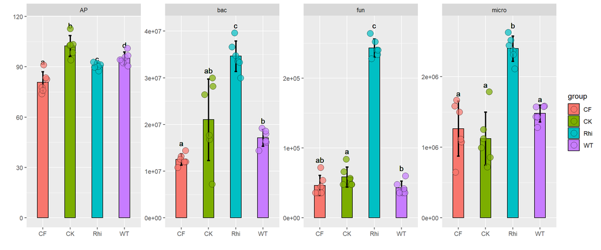

```r
#
result1 = FacetMuiPlotReBoxBar(data = data_wt,num = c(4:7),result = result,sig_show ="abc",ncol = 4 )
result1[[1]]
```

注意以上三种分面展示的目前仅支持字母标注显著性，连线形式的尚未添加。

### 多个分组可视化:GroupBar

使用这种方式可视化一定要注意，坐标轴量度，不同指标范围不一样，因此，单位差距极大的指标一起展示就不太好看了。其次，这里使用line展示会非常混乱，所以我去除了line展示的方式，所以这里没有选择，只能是默认的abc。但是我保留了这个参数，希望以后又更好的方式。

- ylimit = 1.2 :设置Y轴上界范围

```r
colnames(data_wt)
```

```
##  [1] "ID"    "group" "AK"    "AP"    "bac"   "fun"   "micro" "NH4.N"
##  [9] "NO3.N" "pH"    "SOM"   "TN"
```

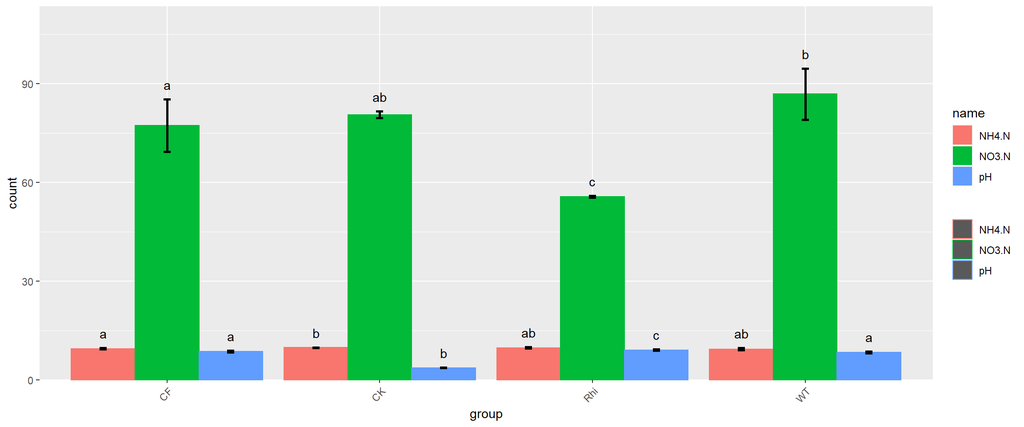

```r
result = MuiKwWlx(data = data_wt,num = c(8:10))
result = GroupBar(data = data_wt,num = c(8:10),result = result,sig_show ="abc",ylimit = 1.2)
# output result
result[[1]]
```

这里我想告诉大家，所有的出图函数都可以提取数据，并且自己设计代码出图。

这里我们提取数据,直接出图也是可以的

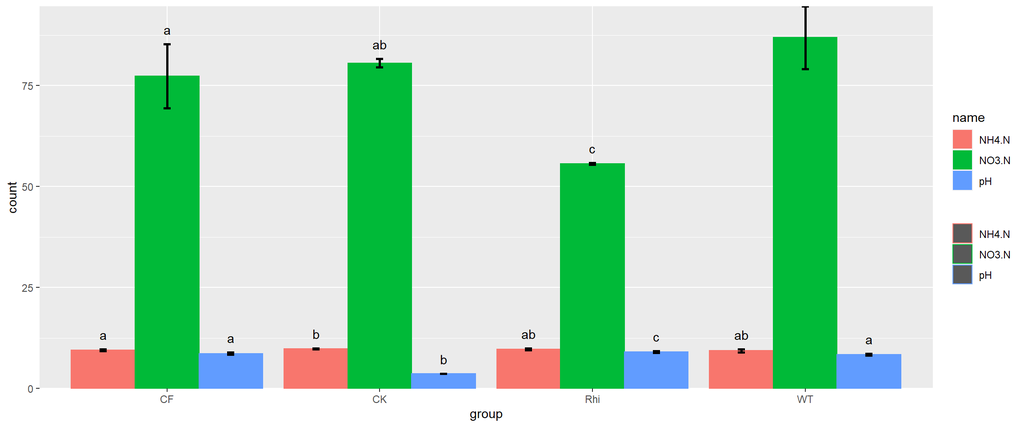

```r
A = result[[2]]

p<-ggplot(A, aes(x=group , y=mean,group = name ))+
    geom_bar(aes(colour= name,fill = name),stat = "identity", width = 0.9,position = "dodge") +

    geom_errorbar(aes(ymin=mean - SD,
                      ymax=mean + SD,group = name),
                  colour="black",width=0.1,size = 1,position = position_dodge(.9))+

    scale_y_continuous(expand = c(0,0))+#,limits = c(0,a)
    labs(
      y="count"
      # y=name_i
      # title = paste("Normality test",p1,"Homogeneity of variance",p2,sep = ":")
    ) +
    geom_text(data=A, aes(x=group, y=mean +SD ,label=groups),position = position_dodge(.9),vjust = -1)+
    guides(color=guide_legend(title = NULL),shape=guide_legend(title = NULL))
p
```

### 单个指标一体化分析（SingleStat）

这个函数可以将我们的目标列做正态检验和方差齐性，然后根据结果选择方差检验或者多重比较方法，最后选择自己需要的出图方式和显著性标记方式展示。

- data：输入数据框，第一列为样本编号，第二列为分组，注意分组标签必须设定为group，第三列以后就是妮妮测定或者收集的指标了
- i：代表您想要进行统计的列，比如：第三列：i = 3
- method_Mc：选择需要使用的多重比较方法，这里又多种方法可供选择：method_Mc == “LSD”;method_Mc == “SNK”;method_Mc == “Duncan”;method_Mc == “scheffe”
- plot：可以选择需要的出图类型，柱状图和箱线图

```r
# ?SingleStat
# # #使用案例
# #输出结果第一个为图片，第二个是统计结果，第三个是统计方法
result = SingleStat(data = data_wt,plot = "bar",method_Mc = "Tukey",i= 4,sig_show ="abc")
```

```
## [1] "aov"
```

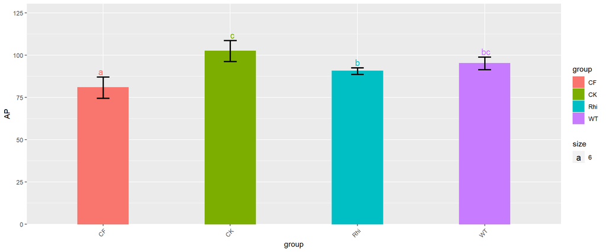

```r
# #导出图片
p = result[[1]]
p
```

可以更换出图方式,当然这里会自动判断使用方差分析，还是非参数检验。选择结果会展示在结果的第三个列表中，可自行查看。

```r
# ?SingleStat
# # #使用案例
# #输出结果第一个为图片，第二个是统计结果，第三个是统计方法
result = SingleStat(data = data_wt,plot = "box",method_Mc = "Tukey",i= 4,sig_show ="abc")
```

```
## [1] "aov"
```

```r
# 提取差异检测结果
result[[2]]
```

```
##     groups group
## CF     a      CF
## CK       c    CK
## Rhi     b    Rhi
## WT      bc    WT
```

```r
# 提取差异检测放啊
result[[3]]
```

```
## [1] "aov"
```

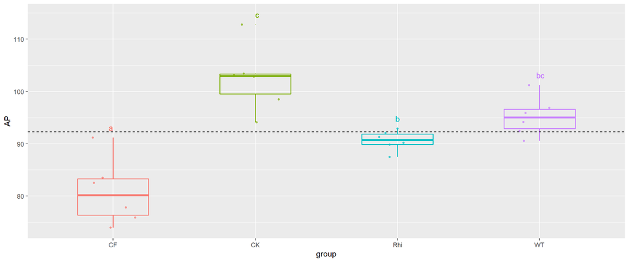

```r
# #导出图片
p = result[[1]]
p
```

```r
# ?SingleStat
# # #使用案例
# #输出结果第一个为图片，第二个是统计结果，第三个是统计方法
result = SingleStat(data = data_wt,plot = "boxbar",method_Mc = "Tukey",i= 4,sig_show ="abc")
```

```
## [1] "aov"
## [1] 4
```

```r
# 提取差异检测结果
result[[2]]
```

```
##     groups group
## CF     a      CF
## CK       c    CK
## Rhi     b    Rhi
## WT      bc    WT
```

```r
# 提取差异检测放啊
result[[3]]
```

```
## [1] "aov"
```

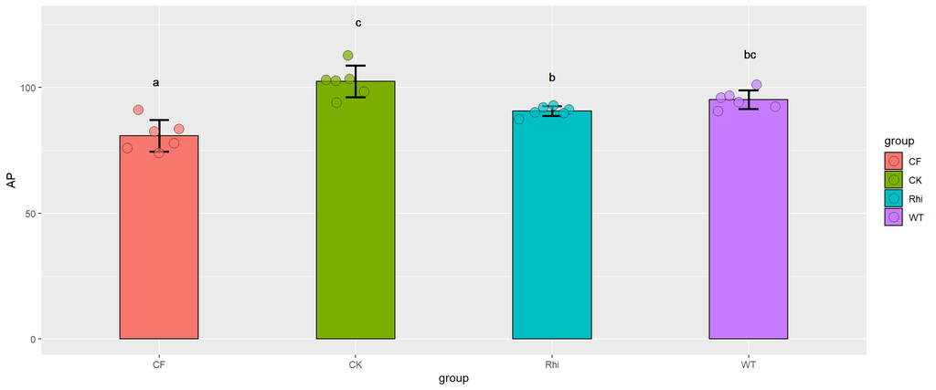

```r
# #导出图片
p = result[[1]]
p
```

### 多个指标一体化分析(MuiStat)

实现了多个指标批量整体运行；这个函数可以将我们的目标列做正态检验和方差齐性，然后根据结果选择方差检验或者多重比较方法，最后选择自己需要的出图方式和显著性标记方式展示。

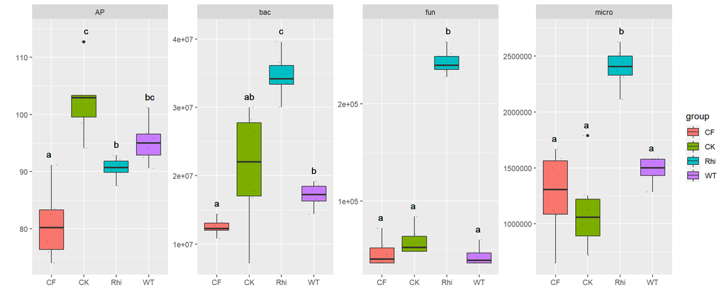

```r
# ?MuiStat
#使用案例
result = MuiStat(data = data_wt,num = c(4:7),method_cv = "leveneTest",method_Mc = "Tukey",sig_show  = "abc",ncol = 4,plot = "box",plottype = "mui")
result[[1]]
```

```r
# 提取方差检测的列
result$aov
```

```
## [1] 4 6 7
```

```r
# 提取f非参数检测的列
result$wlx
```

```
## [1] 5
```

```r
# 提取差异检测结果
result$table
```

```
##      AP fun micro bac
## CF  a    a     a    a
## CK    c  a     a   ab
## Rhi  b    b     b   c
## WT   bc  a     a    b
```

柱状图

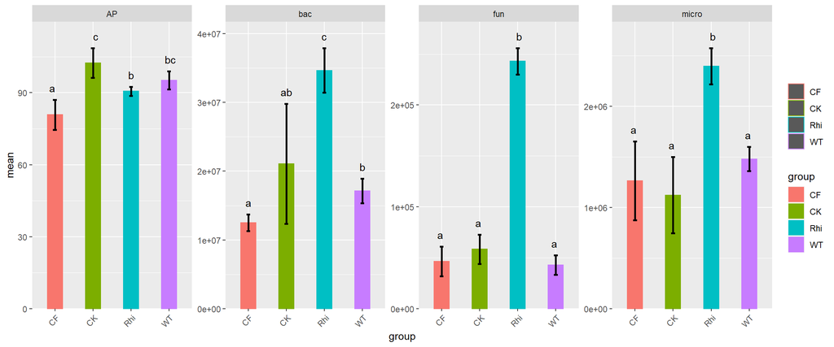

```r
result = MuiStat(data = data_wt,num = c(4:7),method_cv = "leveneTest",method_Mc = "Tukey",sig_show  = "abc",ncol = 4,plot = "bar",plottype = "mui")
result[[1]]
```

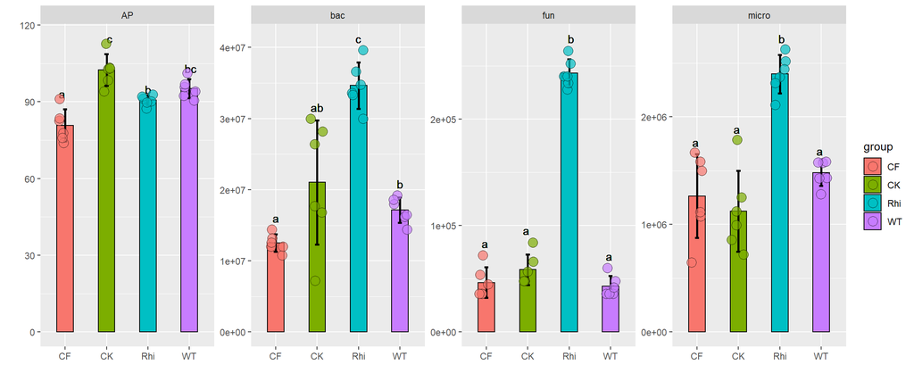

```r
result = MuiStat(data = data_wt,num = c(4:7),method_cv = "leveneTest",method_Mc = "Tukey",sig_show  = "abc",ncol = 4,plot = "boxbar",plottype = "mui")
result[[1]]
```

data：输入数据框，第一列为样本编号，第二列为分组，注意分组标签必须设定为group，第三列以后就是妮妮测定或者收集的指标了

num：代表您想要进行统计的列,这里可以输入多个列，只需要指定列号即可：例如：num = c(4:6)

method_cv：代表选择方差齐性的方法，有两种可供选择：method_cv == “bartlett.test” ;method_cv == “leveneTest”

method_Mc：选择需要使用的多重比较方法，这里又多种方法可供选择：method_Mc == “LSD”;method_Mc == “SNK”;method_Mc == “Duncan”;method_Mc == “scheffe”

plot：可以选择需要的出图类型，柱状图和箱线图

sig_show：代表差异展示方式；sig_show =“abc”是使用字母表示;sig_show =“line”是使用连线和星号表示；如果是NA，那么就不显示显著性结果

ncol：代表分面展示每一行放几张图

plottype：输出图形是分面展示plottype =mui，还是单张展示:plottype == “single”